# PA1_template.Rmd

Christopher Nyberg

January 17, 2015

This is my response to the first assignment in the Reproducable Research class. For privacy reasons, I will set the working directory outside of this markdown file. With the directory set, the data must be loaded into R.

```r
data <- read.csv("activity.csv")
```

Next, let’s just quickly check what this file looks like.

```r
head(data)
```

```
##   steps       date interval
## 1    NA 2012-10-01        0
## 2    NA 2012-10-01        5
## 3    NA 2012-10-01       10
## 4    NA 2012-10-01       15
## 5    NA 2012-10-01       20
## 6    NA 2012-10-01       25
```

```r
tail(data)
```

```
##       steps       date interval
## 17563    NA 2012-11-30     2330
## 17564    NA 2012-11-30     2335
## 17565    NA 2012-11-30     2340
## 17566    NA 2012-11-30     2345
## 17567    NA 2012-11-30     2350
## 17568    NA 2012-11-30     2355
```

```r
str(data)
```

```
## 'data.frame':    17568 obs. of  3 variables:
##  $ steps   : int  NA NA NA NA NA NA NA NA NA NA ...
##  $ date    : Factor w/ 61 levels "2012-10-01","2012-10-02",..: 1 1 1 1 1 1 1 1 1 1 ...
##  $ interval: int  0 5 10 15 20 25 30 35 40 45 ...
```

```r
summary(data)
```

```
##      steps                date          interval
##  Min.   :  0.00   2012-10-01:  288   Min.   :   0.0
##  1st Qu.:  0.00   2012-10-02:  288   1st Qu.: 588.8
##  Median :  0.00   2012-10-03:  288   Median :1177.5
##  Mean   : 37.38   2012-10-04:  288   Mean   :1177.5
##  3rd Qu.: 12.00   2012-10-05:  288   3rd Qu.:1766.2
##  Max.   :806.00   2012-10-06:  288   Max.   :2355.0
##  NA's   :2304     (Other)   :15840
```

Ok. That gives some idea of what is going on here. Now, as I think base R is not very intuitive, I am going to load a couple of packages from the Hadleyverse.

```r
library("tidyr")
library("dplyr")
```

```r
library("ggplot2")
library("lubridate")
library("grid")
library("gridExtra")
```

Great. Let’s just move this into the dplyr wrapper for dataframes and we’re off the the races.

```r
df1 <- tbl_df(data)
df1
```

```
## Source: local data frame [17,568 x 3]
##
##    steps       date interval
## 1     NA 2012-10-01        0
## 2     NA 2012-10-01        5
## 3     NA 2012-10-01       10
## 4     NA 2012-10-01       15
## 5     NA 2012-10-01       20
## 6     NA 2012-10-01       25
## 7     NA 2012-10-01       30
## 8     NA 2012-10-01       35
## 9     NA 2012-10-01       40
## 10    NA 2012-10-01       45
## ..   ...        ...      ...
```

One last thing. What sort of data are we working with here?

```r
sapply(df1,class)
```

```
##     steps      date  interval
## "integer"  "factor" "integer"
```

Date as factor. Likely not a dealbreaker here, but something that may need to be coerced later.

First question, make a histogram of total number of steps taken each day.

```
## stat_bin: binwidth defaulted to range/30. Use 'binwidth = x' to adjust this.
```

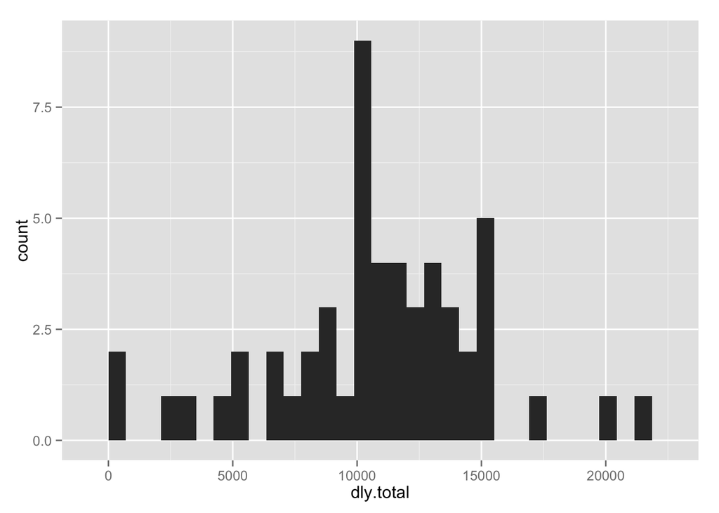

```r
hist_data <- df1 %>%
    group_by(date) %>%
    summarise(dly.total = sum(steps))

p0 <- qplot(dly.total,data=hist_data,geom = "histogram")
p0
```

Second question, create and report median and mean steps taken each day.

```r
df2 <- df1 %>%
    group_by(date) %>%
    summarise(
        total = sum(steps, na.rm=TRUE),
        mean = mean(steps, na.rm=TRUE),
        median = median(steps, na.rm=TRUE)
        )
df2
```

```
## Source: local data frame [61 x 4]
##
##          date total     mean median
## 1  2012-10-01     0      NaN     NA
## 2  2012-10-02   126  0.43750      0
## 3  2012-10-03 11352 39.41667      0
## 4  2012-10-04 12116 42.06944      0
## 5  2012-10-05 13294 46.15972      0
## 6  2012-10-06 15420 53.54167      0
## 7  2012-10-07 11015 38.24653      0
## 8  2012-10-08     0      NaN     NA
## 9  2012-10-09 12811 44.48264      0
## 10 2012-10-10  9900 34.37500      0
## ..        ...   ...      ...    ...
```

Cool. So now we want to resort this data. We want to see the average steps taken at each five minute interval. Let’s give it a shot!

```r
df3 <- df1 %>%
    group_by(interval) %>%
    summarise(
        mean = mean(steps, na.rm=TRUE)
        )
df3
```

```
## Source: local data frame [288 x 2]
##
##    interval      mean
## 1         0 1.7169811
## 2         5 0.3396226
## 3        10 0.1320755
## 4        15 0.1509434
## 5        20 0.0754717
## 6        25 2.0943396
## 7        30 0.5283019
## 8        35 0.8679245
## 9        40 0.0000000
## 10       45 1.4716981
## ..      ...       ...
```

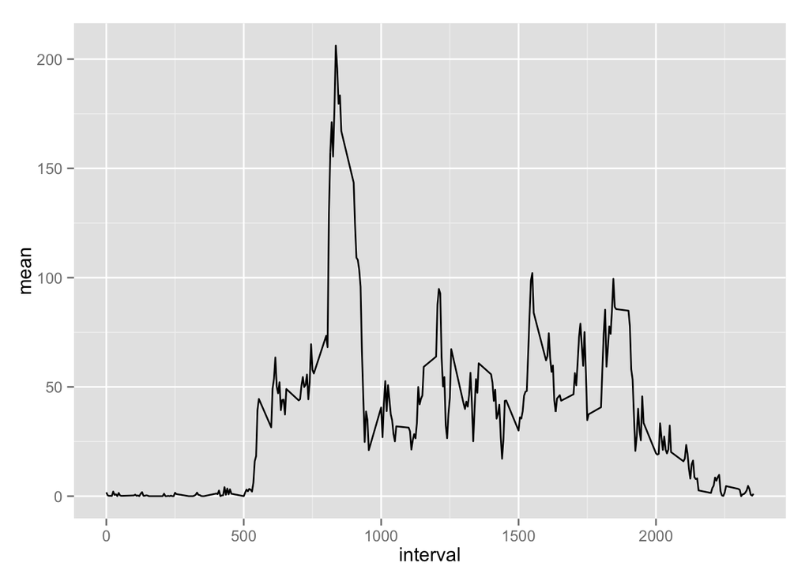

```r
ggplot() + geom_line(data = df3, aes(x = interval, y = mean))
```

Great! Now we want to know which interval has the highest average number of steps.

```r
filter(df3,mean==max(df3$mean))
```

```
## Source: local data frame [1 x 2]
##
##   interval     mean
## 1      835 206.1698
```

Looks like 8:35 AM is a very productive time, indeed.

Now with that out of the way, we need to deal with all of these blank values. Naturally, the first question is, how many of these NAs do I have, anyway?

```r
table(is.na(df1))
```

```
##
## FALSE  TRUE
## 50400  2304
```

2,304. That is a rather large number. I guess we will need to do something about that.

Luckily, it appears all of the missing values are steps.

```r
table(is.na(df1$steps))
```

```
##
## FALSE  TRUE
## 15264  2304
```

The second step is to devise a naive method of dealing with these blank values. I think I will take the mean value at each interval and use that as a plug for the NAs. Luckily for us, we can just recycle that code for df3 from above. Using that, let’s create a new dataframe called dfM, short for Master Dataframe, which we will use as processed data for the rest of the study.

```r
testVal <- ifelse(is.na(df1$steps),
                  df3$mean[
                            match(df1$interval,df3$interval)
                            ],
                  df1$steps
                  )

dfM <- data.frame(steps = testVal,date = df1$date, interval = df1$interval)

tbl_df(dfM)
```

```
## Source: local data frame [17,568 x 3]
##
##        steps       date interval
## 1  1.7169811 2012-10-01        0
## 2  0.3396226 2012-10-01        5
## 3  0.1320755 2012-10-01       10
## 4  0.1509434 2012-10-01       15
## 5  0.0754717 2012-10-01       20
## 6  2.0943396 2012-10-01       25
## 7  0.5283019 2012-10-01       30
## 8  0.8679245 2012-10-01       35
## 9  0.0000000 2012-10-01       40
## 10 1.4716981 2012-10-01       45
## ..       ...        ...      ...
```

Let’s just test to really be sure our data is filled in.

```r
table(is.na(dfM))
```

```
##
## FALSE
## 52704
```

Great! Now let’s re-run the analysis from above and see what the charts look like now.

```
## stat_bin: binwidth defaulted to range/30. Use 'binwidth = x' to adjust this.
```

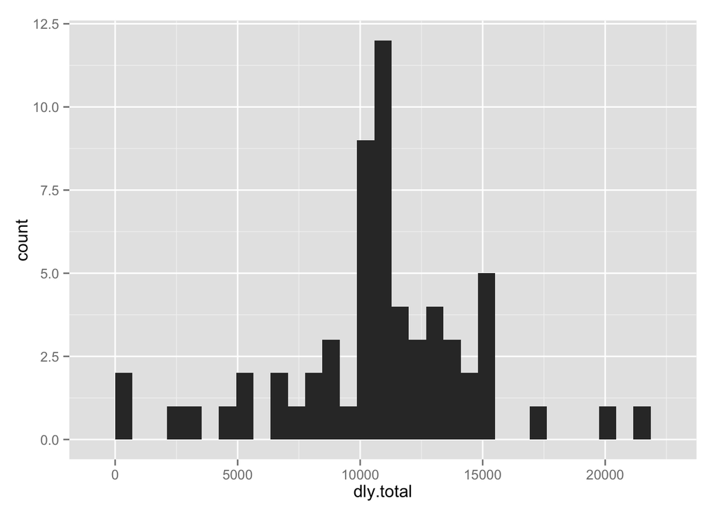

```r
hist_data1 <- dfM %>%
    group_by(date) %>%
    summarise(dly.total = sum(steps))

p1 <- qplot(dly.total,data=hist_data1,geom = "histogram")
p1
```

So let’s see how much this has changed things.

```
## stat_bin: binwidth defaulted to range/30. Use 'binwidth = x' to adjust this.
## stat_bin: binwidth defaulted to range/30. Use 'binwidth = x' to adjust this.
```

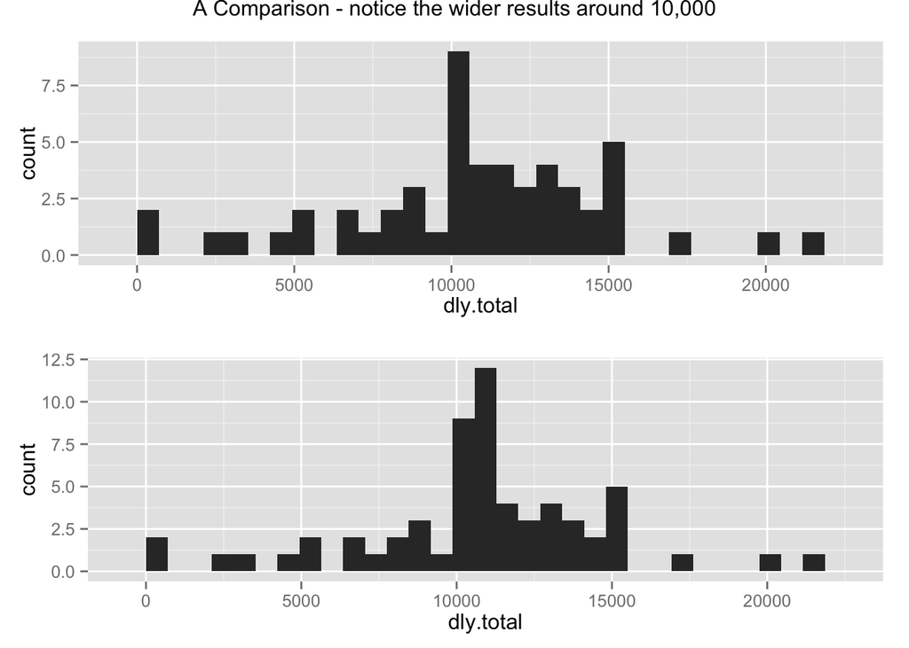

```r
grid.arrange(p0, p1, ncol = 1, main = "A Comparison - notice the wider results around 10,000")
```

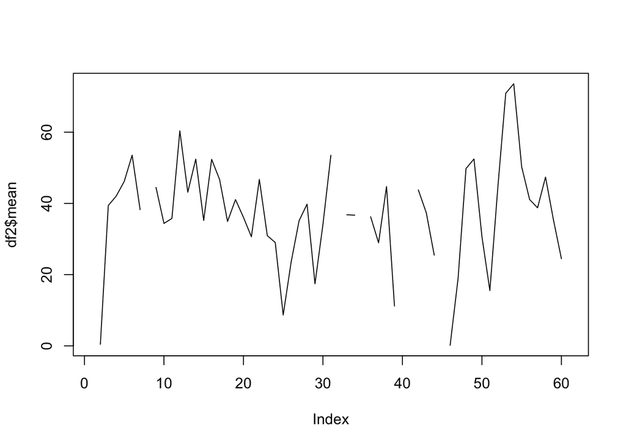

```r
df4 <- dfM %>%
    group_by(date) %>%
    summarise(
        total = sum(steps, na.rm=TRUE),
        mean = mean(steps, na.rm=TRUE),
        median = median(steps, na.rm=TRUE)
        )

plot(df2$mean,type="l")
```

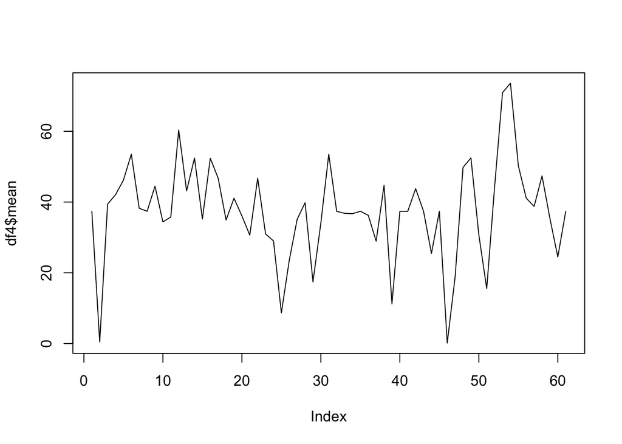

```r
plot(df4$mean,type="l")
```

```r
df1$interval[is.na(df1$steps)]
```

[output not shown]

[output cut: 163 more lines]

Alas, the time has come where we have to coerce our time data. Luckily, lubridate takes a lot of the ugliness of working with dates out of R.

```r
dfM$date <- ymd(dfM$date)
```

Not too bad after all.

Now we need to separate weekdays and weekends and see if there is any difference between the two.

```r
dayType <- weekdays(dfM$date)
dayType <- ifelse(dayType == "Sunday" | dayType =="Saturday","weekend","weekday")
dfM1 <- cbind(dfM,dayType)
```

Finally, let’s plot the average steps taken on weekday and weekend days by 5 minute interval.

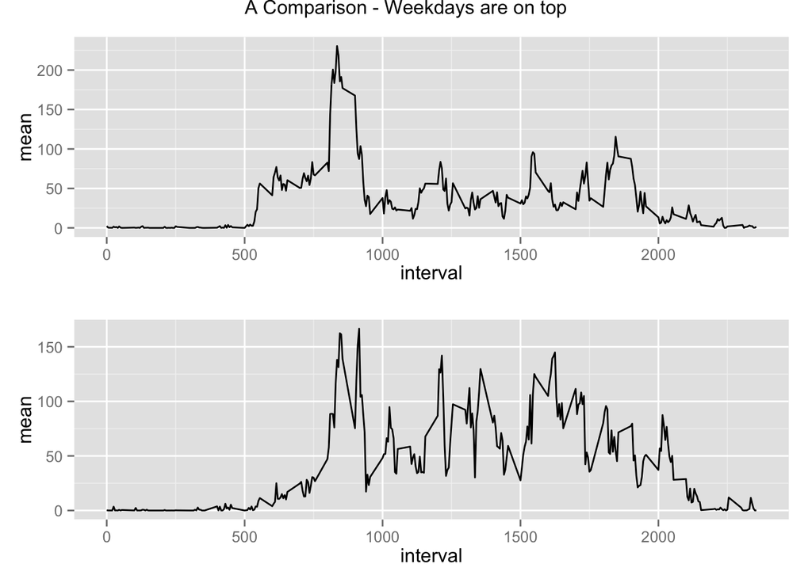

```r
dfWeekday <- dfM1 %>%
    group_by(interval) %>%
    filter(dayType == "weekday") %>%
    summarise(
        mean = mean(steps, na.rm=TRUE)
        )

dfWeekend <- dfM1 %>%
    group_by(interval) %>%
    filter(dayType == "weekend") %>%
    summarise(
        mean = mean(steps, na.rm=TRUE)
        )

p3 <- ggplot() + geom_line(data = dfWeekday, aes(x = interval, y = mean))

p4 <- ggplot() + geom_line(data = dfWeekend, aes(x = interval, y = mean))

grid.arrange(p3, p4, ncol = 1, main = "A Comparison - Weekdays are on top")
```

That is the report as requested.

Thank you for your time and consideration.